# COVID-19 Testing Kit: An Example of Binary Classification

FHL

9/13/2020

## Bayes rule

The simple form of the famous [Bayes rule](https://en.wikipedia.org/wiki/Bayes%27_theorem) is the following: $P(A\ and\ B)=P(A|B)*P(B)=P(B|A)*P(A)$. It is very useful in understanding a lot of important concepts and techniques, and here we briefly explain one of them–binary classification.

### Binary classification

Given the result some test, we want to classifiy the target object into one of two groups. As an example, we want to classify a person as either with COVID-19 (Infected, denoted by I) or not (denoted by N) based on the result of some lab test (either ‘+’ or ‘-’).

- Here are a few concepts are of great interests
  - Sensitivity: P(+|I). This measures the rate of indentifying an infected person.
  - Specificity: P(-|N). This measures the rate of correctly letting a healthy person pass the test.
  - True positive rate (TP) and false positive rate (FP): P(I|+), P(N|+)
  - True negative rate (TN) and false negative rate (FN): P(N|-), P(I|-)
- Ideally, we want to design some classifying method that will catch (almost) all the true patients while letting (almost) all the healthy people go. Therefore, high TP and TN rate are desirable properties of such kind of tests.
- However, what one improve control in the test is usually the sensitivity and specificity. When P(+|I) and P(-|N) are high, then we expect that the test should be an accurate way to classify the patients (or objects), but the true meaning of being ‘accurate’ may need more precise measurement.

#### The COVID-19 Test example

Accoring to some [online news](https://www.theverge.com/2020/8/26/21403432/fda-authorizes-binaxnow-covid-19-test-abbott-cheap-fast), FDA has authorized fast COVID-19 test called BinaxNOW. It takes 15 min to get the results at the cost of 5 USD. And it is said that the sensitivity is 97.1% while the specificity is 98.5% in lab.

- Question: how accurate is this test? While the sensitivity and specificity seem to be reasonably good, what we truly care about may be P(I|+) and P(N|-). So, what is the value of the true positive rate? We need to make some assumptions to answer this questions. Here is why. What we know are $P(+|I)=97.1%$ and $P(-|N)=98.5%$. From the Bayes rule, we have
  $$P(I|+)= \frac{P(I\ and \ +)}{P(+)}= \frac{P(+|I)P(I)}{P(+)}$$
  .

But the problem is how to get $P(I)$ and $P(+)$. Well, by Bayes rule again, we have
$$P(+)=P(I\ and \ +)+P(N\ and \ +)= P(+|I)P(I)+ P(+|N)P(N)$$
.

And we know that $P(N)=1-P(I)$. Therefore, the only missing pice is $P(I)$. This quantity is called the **prevalence**. Now, let us assume that $0.5%$ of the target group have been infected by COVID-19, then we set $P(I)=0.5%$ and $P(N)=1-P(I)=99.5%$. After some algebra, we can get $P(I|+)=24.54%$ using the following code

```r
sensitivity=0.971 #P(+|I)
specificity=0.985 #P(-|N)
prevalence=0.005 #P(I)
pos_rate=sensitivity*prevalence+(1-specificity)*(1-prevalence)
neg_rate=1-pos_rate
TP=sensitivity*prevalence/pos_rate
print(paste0('True Positive Rate P(I|+)=',round(TP*100,digits=2),'%'))
```

```
[1] "True Positive Rate P(I|+)=24.54%"
```

Now is the interesting part: the true positive rate is just below 1/4! Does this surprise you? Does it mean that the test is terrible? Think about it before we move on.

In fact the seemingly high sensitivity and specificity and the seemingly low true positive rate is due to the low prevalence. Let us do some numerical experiment by chaning the prevalence while keeping everything else unchanged

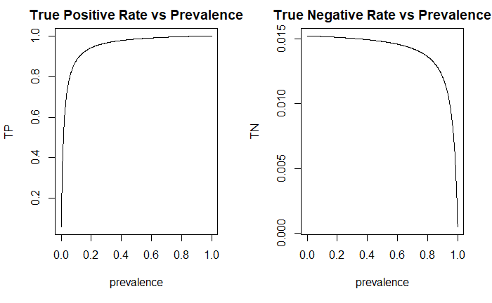

```r
prevalence=seq(from=0.001, to=0.999, by=0.001)
pos_rate=sensitivity*prevalence+(1-specificity)*(1-prevalence)
neg_rate=1-pos_rate
TP=sensitivity*prevalence/pos_rate
TN=(1-specificity)*(1-prevalence)/neg_rate
par(mfrow=c(1,2))
plot(prevalence, TP, type='l',main='True Positive Rate vs Prevalence')
plot(prevalence, TN, type='l',main='True Negative Rate vs Prevalence')
```

When the prevalence becomes $5\%$ (as is the case in some counties of [California](https://www.cdph.ca.gov/Programs/CID/DCDC/Pages/Immunization/ncov2019.aspx) state in summer 2020), the TP rate would become more than 3/4.

- The ‘low true positive rate’ revisit. Previously, when the prevalence is low (P(I)=0.5%), we have the true positive rate equal to about 1/4. It seems to be kind of low– the positive test is only right in 1 out of four cases! However, this number is much higher than the prevalence. What is more, the chance of haveing a positive test result is $P(+)=P(+|I)P(I)+P(+|I)P(I)+ P(+|N)P(N)=1.978\%$, which means only about $2\%$ of the general population will be positive for such a test. However, follow-up protocol should be in place for the people with a positive test result in order to properly utilize such a fast testing kit.